# Stat 302 Project 3 Part 2

Ian Renshaw

3/18/2021

# Introduction

This is the second part of Project 3 for STAT 302. This part of the project shows my new abilities in setting up a data analysis project pipeline. The analysis makes use of the my_rf_cv() function from earlier code. This analysis will compare the cross-validation error when using different numbers of folds.

### Boxplot comparing CVE for different numbers of folds across 30 simiulations:

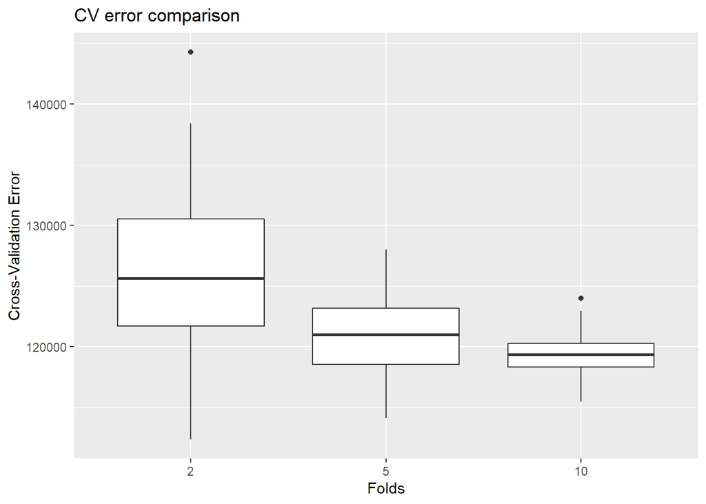

Comparison of summary statistics for the CVE of different numbers of folds across 30 simiulations:

[output not shown]

The boxplot and table suggets that the cross-validation error decreases as the number of folds increases. With 2 folds, the error seems to be significantly higher whereas the difference in error between 5 and 10 folds is less noticeable. However, the boxplots suggest that there is less variance in error when there are 10 folds, compared to when there are 5. The table suggests the same, as cross-validation with 10 folds had the lowest standard deviation in its error. The table also shows that with only 2 folds, the standard deviation is much higher. The results suggest that the mean and standard deviation of the error decrease as the number of folds increase. I believe that this is the case because when we have a higher number of folds, this means that the amount of data we use as training data for our prediction increases, meaning that there is less room for error.

Save output as files:

```r
# Save boxplot as png to /Output/Figures
ggsave("../Output/Figures/folds_boxplot.png", folds_boxplot)
# Save table of summary statistics as an rds file to /Output/Results
saveRDS(sum_stats, "../Output/Results/sum_stats.rds")

# Save data frame of simulation results as a csv file to /Output/Results
write.csv(sim_results, "../Output/Results/sim_results.csv")
```

# Conclusion

In conclusion, through the second part of project 3, I have learned how to navigate a data analysis project pipeline. I set up a cross-validation analysis using the my_rf_cv function and adapted earlier code to fit the project pipeline. The my_rf_cv function is loaded from the Code folder and uses the my_penguin data from the Data folder. The generated output is stored in the Output folder, in the respective subfolders.

#### Code Appendix

```r
source("../Code/my_rf_cv.R")

# Random forest cross-validation with 2 folds
fold_2 <- c(1:30)
for(i in 1:30) {
  fold_2[i] <- my_rf_cv(2)
}

# Random forest cross-validation with 5 folds
fold_5 <- c(1:30)
for(i in 1:30) {
  fold_5[i] <- my_rf_cv(5)
}

# Random forest cross-validation with 10 folds
fold_10 <- c(1:30)
for(i in 1:30) {
  fold_10[i] <- my_rf_cv(10)
}

# data frame of results from the simulations
sim_results <- data.frame("two_folds" = fold_2, "five_folds" = fold_5, "ten_folds" = fold_10)

# Create data frame for CVE to use for plotting
df <- data.frame(CVE = fold_2, folds = "2")
df <- rbind(df, data.frame(CVE = fold_5, folds = "5"))
df <- rbind(df, data.frame(CVE = fold_10, folds = "10"))

# Boxplot comparing CVE for different numbers of folds
folds_boxplot <- ggplot(data = df, aes(x = folds, y = CVE)) +
  geom_boxplot() +
  labs(x = "Folds", y = "Cross-Validation Error", title = "CV error comparison")

# Table comparing summary statistics of CVE for different numbers of folds
sum_stats <- data.frame(folds = 2,
           min = summary(fold_2)[[1]],
           first_quartile = summary(fold_2)[[2]],
           median = summary(fold_2)[[3]],
           mean = summary(fold_2)[[4]],
           third_quartile = summary(fold_2)[[5]],
           max = summary(fold_2)[[6]],
           variance = var(fold_2),
           standard_deviation = sd(fold_2)) %>%
    rbind(data.frame(folds = 5,
           min = summary(fold_5)[[1]],
           first_quartile = summary(fold_5)[[2]],
           median = summary(fold_5)[[3]],
           mean = summary(fold_5)[[4]],
           third_quartile = summary(fold_2)[[5]],
           max = summary(fold_5)[[6]],
           variance = var(fold_5),
           standard_deviation = sd(fold_5))) %>%
    rbind(data.frame(folds = 10,
           min = summary(fold_10)[[1]],
           first_quartile = summary(fold_10)[[2]],
           median = summary(fold_10)[[3]],
           mean = summary(fold_10)[[4]],
           third_quartile = summary(fold_10)[[5]],
           max = summary(fold_10)[[6]],
           variance = var(fold_10),
           standard_deviation = sd(fold_10)))



# Save boxplot as png to /Output/Figures
ggsave("../Output/Figures/folds_boxplot.png", folds_boxplot)

# Save table of summary statistics as an rds file to /Output/Results
saveRDS(sum_stats, "../Output/Results/sum_stats.rds")

# Save data frame of simulation results as a csv file to /Output/Results
write.csv(sim_results, "../Output/Results/sim_results.csv")
```